# Qual a relação entre a ideologia política dos governadores e a Violência de Estado?

### Tema central na agenda pública brasileira, a problemática da segurança é abordada de maneiras distintas por políticos e partidos

### Na literatura, o conceito de Policy Process considera a interação entre instituições, atores, ideias e crenças na formulação de políticas, sendo um arcabouço para entender como mudanças na esfera governamental podem influenciar decisões relacionadas à segurança pública

### Em um ambiente de novas orientações políticas no poder, é esperado que haja uma modificação na implementação das políticas públicas, bem como da abordagem dos tópicos prioritários

### Portanto, com a ascensão de grupos políticos de direita no Brasil, levantamos questões sobre a possível adoção de políticas punitivas e seus impactos na violência estatal

## O trabalho busca responder à pergunta:

### Qual a relação entre a ideologia política dos governadores e a Violência de Estado?

### Ao explorar essas dinâmicas, o estudo pretende contribuir para a compreensão do papel da ideologia política na formulação e implementação de políticas públicas de segurança no Brasil, bem como aos estudos das novas direitas no poder.

## Método

### A partir da realização de Regressões Lineares, vamos verificar o peso da ideologia partidária dos governadores no comportamento de diferentes variáveis de Violência de Estado.

## Fontes de dados

- Crimes/Ocorrências: Anuário Brasileiro de Segurança Pública
- Classificação Ideológica: Brazilian Legislative Survey (Zucco et al.) e Bolognesi et al.

## Limpeza e organização dos dados

### Os dados foram coletados e organizados no R, inicialmente reunindo todas as ocorrências e calculando suas taxas por 100 mil habitantes, usando a estimativa populacional do Ipea Data

### Em sequência, agrupamos os valores para os três mandatos incluídos na amostra

#### (2011-2014; 2015-2018; 2019-2022)

### Posteriormente, os dados de classificação ideológica foram adicionados a depender do partido do governador que exerceu aquele mandato

### Por fim, chegamos a uma base de dados que reúne as taxas de crimes médias por 100 mil habitantes para o período de cada mandato e as respectivas classificações ideológicas

## Hipótese

## H1: Estados governados por políticos de direita tendem a apresentar maiores taxas de violência de Estado

Vamos aplicar uma regressão linear entre as variáveis integrantes ao conceito de violência de Estado e a variável de classificação ideológica (numérica)

## Variáveis (por 100 mil habitantes):

- Mortes durante intervenções da polícia militar
- Mortes durante intervenções da polícia civil
- População carcerária

## Resultados Preliminares

## Regressão 1

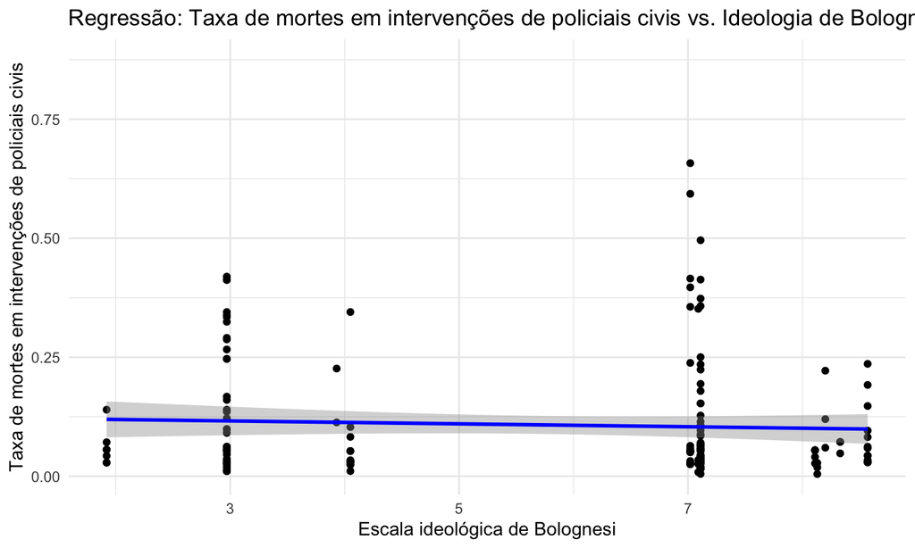

## Regressão 2

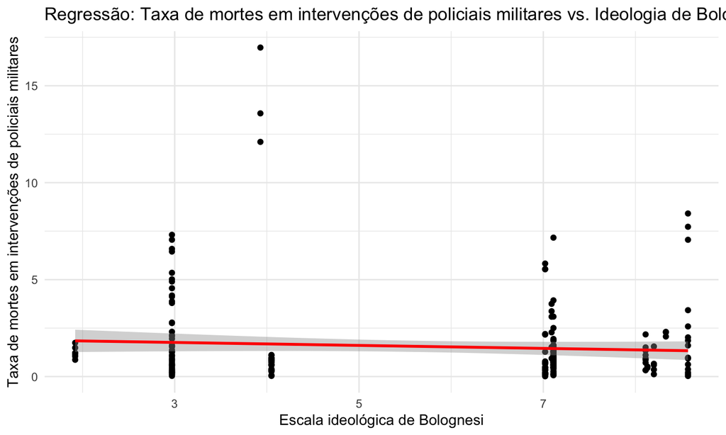

## Regressão 3

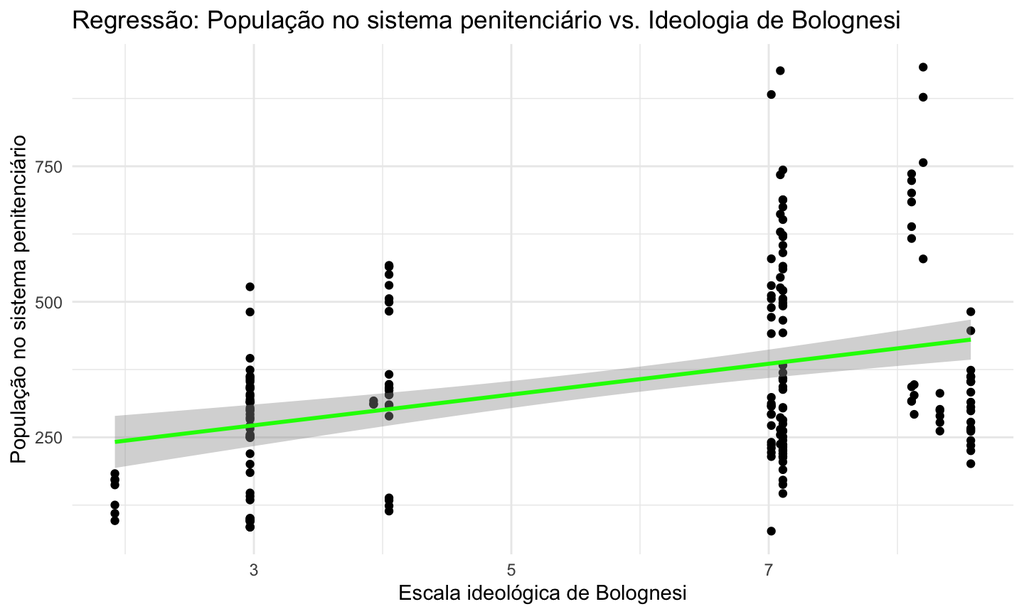

## Conclusões

Os resultados preliminares indicaram que apenas o aumento da população carcerária é estatisticamente significativo à posição ideológica dos governadores estaduais.

No entanto, uma análise de um tema amplo como a segurança pública exige a inserção de covariáveis para o fortalecimento do modelo.

Os testes aqui apresentados devem ser utilizados apenas como referência para a conclusão da disciplina e um marco inicial no desenvolvimento da dissertação de mestrado.